# 第11講 クラスタ分析

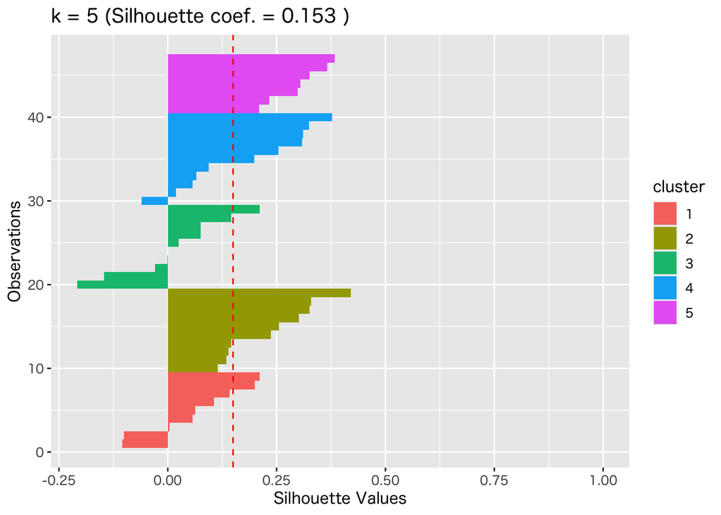

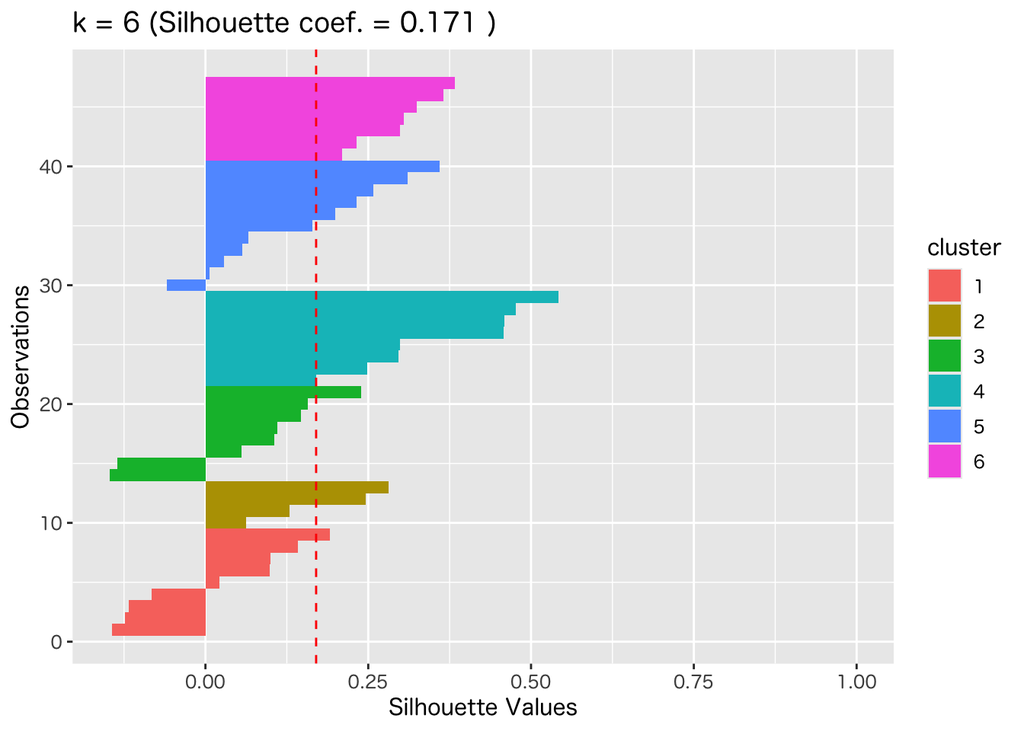

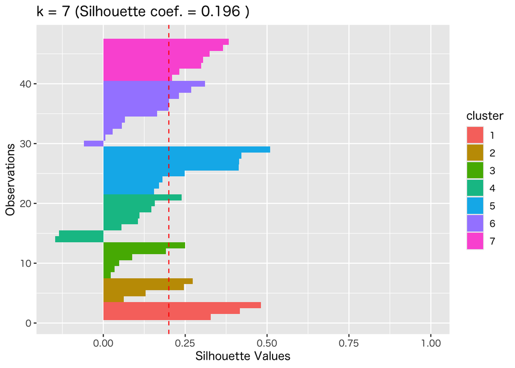

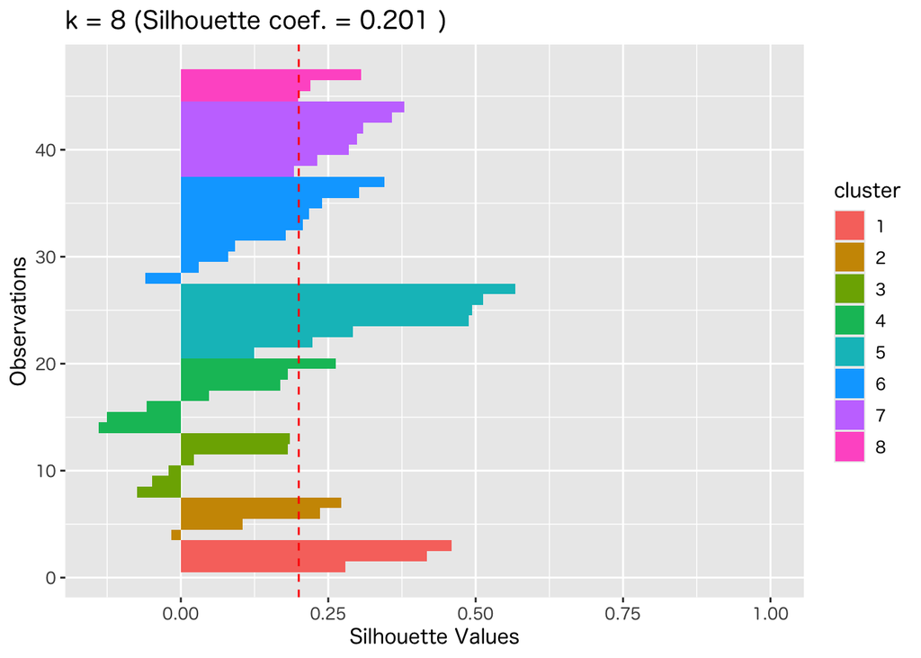

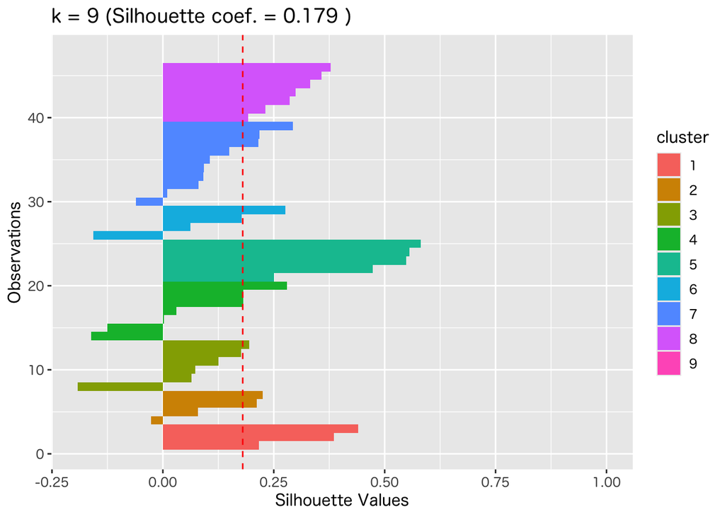

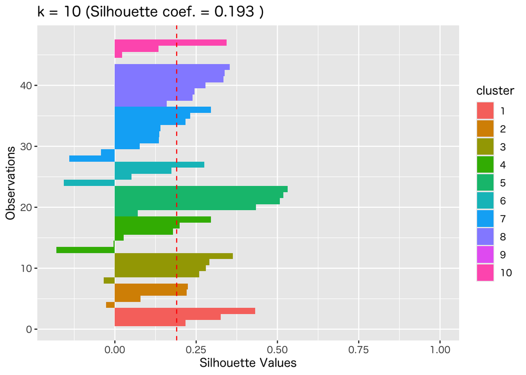

```r
for(k in 5:10) {
    foo <-
        om_data |>
        column_to_rownames(var = "都道府県名") |>
        select(where(is.double)) |>
        pam(k = k)
    p <- foo |>
        silhouette() |>
        autoplot() +
        labs(title = paste("k =", k, "(Silhouette coef. =",
                           round(foo$silinfo$avg.width, digits = 3), ")"))
    print(p)
}
```

悪いシルエット係数が少ないという意味で k=7 が良さそう．

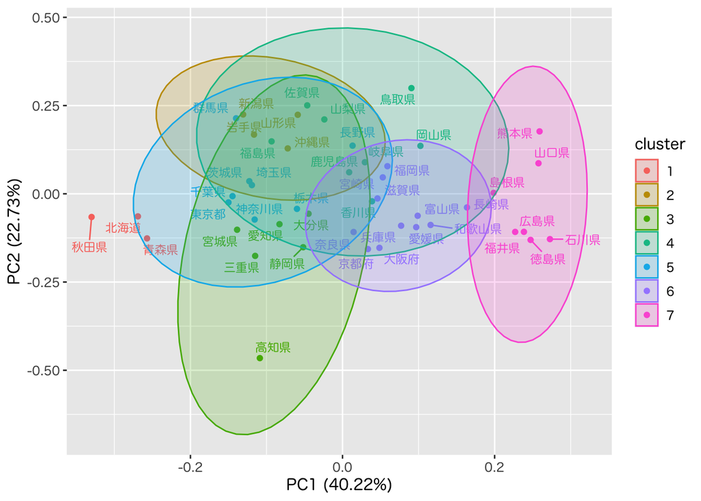

```r
k <- 7
om_data |>
    column_to_rownames(var = "都道府県名") |>
    select(where(is.double)) |>
    pam(k = k) |>
    autoplot(frame = TRUE,
             frame.type = "norm",
             label = TRUE,
             label.repel = TRUE,
             label.size = 3,
             label.show.legend = FALSE)
```

階層的クラスタリングでもシルエット係数を計算することができる．

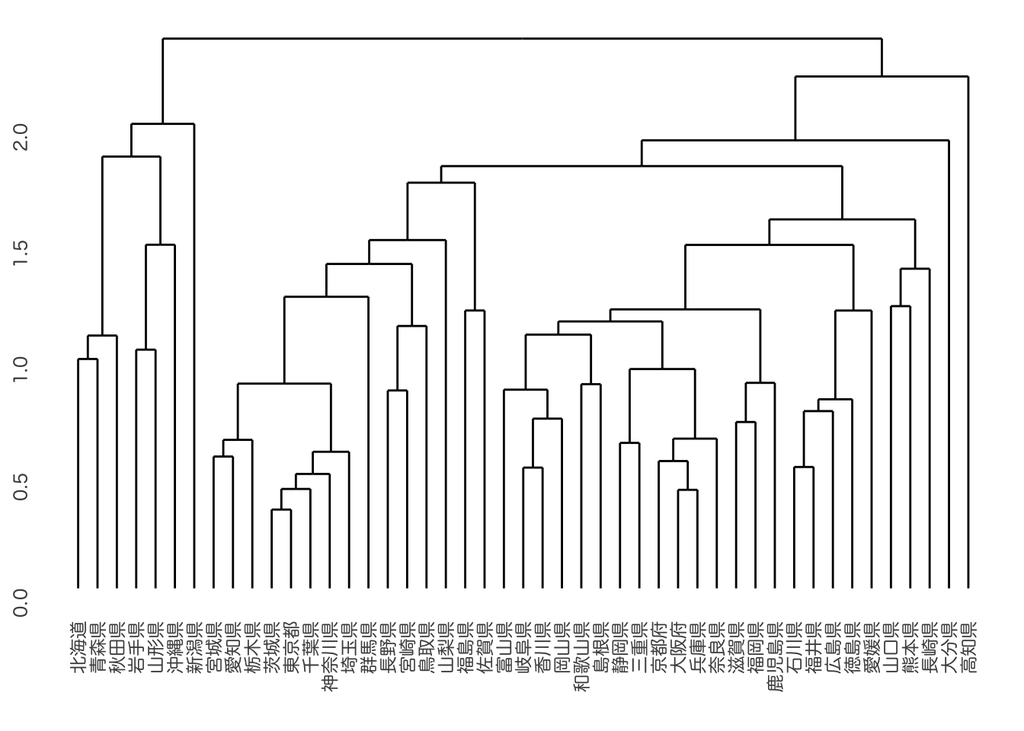

```r
om_agnes <- agnes(om_df_hel)
om_agnes |> as.dendrogram() |>
    ggdendrogram()
```

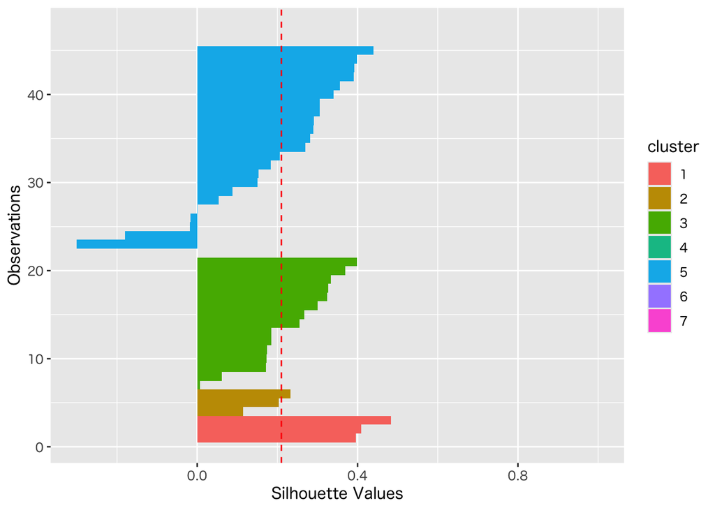

```r
silhouette(cutree(om_agnes, k = k),
           daisy(om_df_hel)) |> # 距離行列が必要
    autoplot()
```

シルエット係数のグラフはクラスタ毎に降順(大きいものが上)に並べ替えられている． グラフに合わせた要素名を取り出すには例えば以下のようにすれば良い．

```r
silhouette(cutree(om_agnes, k = k), daisy(om_df_hel)) |>
    as_tibble() |>
    mutate(prefecture=rownames(om_df_hel)) |>
    arrange(desc(cluster), desc(sil_width))
```

```
# A tibble: 47 × 4
   cluster neighbor sil_width prefecture
     <dbl>    <dbl>     <dbl> <chr>
 1       7        5     0     大分県
 2       6        5     0     高知県
 3       5        3     0.440 島根県
 4       5        6     0.399 徳島県
 5       5        3     0.392 兵庫県
 6       5        6     0.391 福井県
 7       5        7     0.356 広島県
 8       5        6     0.340 大阪府
 9       5        3     0.306 愛媛県
10       5        3     0.306 富山県
# ℹ 37 more rows
```